# Parametric Survival Analysis

Author

Group 3 Dr Omar Bin Nazmi, Dr Ahmad Syahid Bin Ibrahim, Dr Mohd Hilmi Bin Mat Husain

```r
options(repos = c(CRAN = "https://cran.rstudio.com/"))
```

## 0.1 Quarto

GET502 Analisa Data Kategorikal Lanjutan (Advanced Categorical Data Analysis) Assignment 2: Parametric Survival Analysis Models

### 0.1.1 Report Prepared By

1. Dr Omar Bin Nazmi

2. Dr Ahmad Syahid bin Ibrahim

3. Dr Muhd Hilmi Bin Mat Husain

[figure not shown]

Logo

# 1 Introduction

A researcher assembled data from Cancer Registry in Kelantan from 2008-2017 and follow up period 2018-2022 on Non Hodgkin Lymphoma patients aged 18 Years and above. This datasets contain 438 patients.The duration tracked are from the day of the notification until the date of death. The date of death is then verified with Jabatan Pendaftaran Negara to ensure the internal validity of the study. It incorporate, sociodemographic characteristic, stages of NHL, histological subtypes which are indolent, aggresive and very aggressive and chemotherapy treatment. Parametric survival analysis of this study allow estimations of survival times and prediction, however it should be proceed with caution as the exact distribution of survival time of NHL are varied.

# 2 Description of Dataset

## 2.1 Variables

Independent Variable

Dependent Variable

Events : Alive or censored : 0, Death : 1

# 3 Workflow Plan

## 3.1 Prepare Environment

```r
install.packages("epiR")
install.packages("SurvRegCensCov")
install.packages("flexsurv")
library(SurvRegCensCov)
library(epiR)
library(haven)
library(tidyverse)
library(dagitty)
library(ggdag)
library(dplyr)
library(readxl)
library(survminer)
library(gtsummary)
library(survival)
library(survminer)
library(flexsurv)
library(gtsummary)
library(gt)
```

```r
Data_Survival_NHL <- read_excel("C:/Users/H P/OneDrive - The Goose and Duck/Desktop/parametric survival/Data Survival NHL1.xlsx")
summary(Data_Survival_NHL)
```

```
 Agelesstahn600morethan601 Indolent0,Aggressive1very aggressive2latest
 Min.   :0.0000            Min.   :0.000
 1st Qu.:0.0000            1st Qu.:1.000
 Median :0.0000            Median :1.000
 Mean   :0.3562            Mean   :1.007
 3rd Qu.:1.0000            3rd Qu.:1.000
 Max.   :1.0000            Max.   :2.000
 stage120stage31satge42unkown3 Chemotherapy 0= NO, Yes= 1, 2= unknown
 Min.   :0.000                 Min.   :0.0000
 1st Qu.:2.000                 1st Qu.:0.0000
 Median :3.000                 Median :1.0000
 Mean   :2.459                 Mean   :0.6119
 3rd Qu.:3.000                 3rd Qu.:1.0000
 Max.   :3.000                 Max.   :2.0000
 Sex male : 1, female 0 duration_i_month    Alive:0_Death:1
 Min.   :0.0000         Min.   :  0.03288   Min.   :0.0000
 1st Qu.:0.0000         1st Qu.:  1.77534   1st Qu.:1.0000
 Median :1.0000         Median : 10.50411   Median :1.0000
 Mean   :0.6096         Mean   : 37.53590   Mean   :0.7694
 3rd Qu.:1.0000         3rd Qu.: 67.69315   3rd Qu.:1.0000
 Max.   :1.0000         Max.   :180.09863   Max.   :1.0000
```

```r
# Define updated DAG including type
dag <- dagitty("
dag {
  age -> chemo
  age -> survival
  stage -> chemo
  stage -> survival
  gender -> chemo
  gender -> survival
  type -> chemo
  type -> survival
  chemo -> survival
}
")
```

```r
dag_tidy <- tidy_dagitty(dag) %>%
  mutate(role = case_when(
    name %in% c("age", "stage", "gender", "type") ~ "confounder",
    name == "chemo" ~ "exposure",
    name == "survival" ~ "outcome",
    TRUE ~ "other"
  ))
```

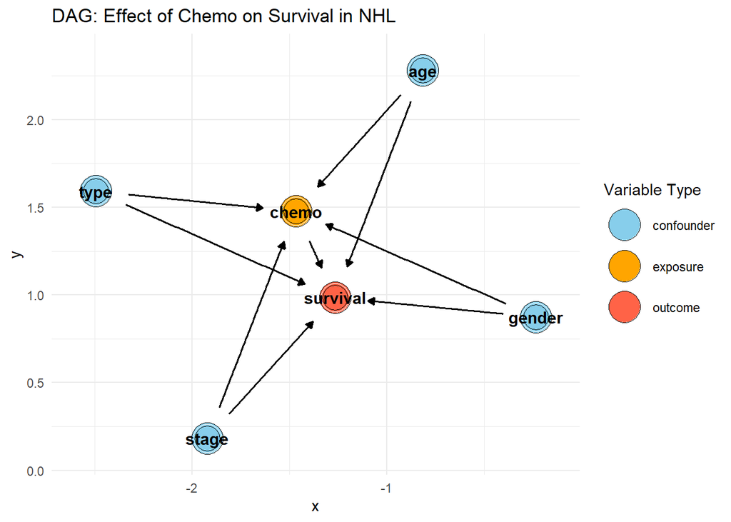

```r
ggplot(dag_tidy, aes(x = x, y = y, xend = xend, yend = yend)) +
  geom_dag_edges() +
  geom_dag_node(aes(fill = role), shape = 21, size = 10) +
  geom_dag_text(color = "black") +
  scale_fill_manual(values = c(
    "confounder" = "skyblue",
    "exposure" = "orange",
    "outcome" = "tomato"
  )) +
  theme_minimal() +
  labs(fill = "Variable Type", title = "DAG: Effect of Chemo on Survival in NHL")
```

Using DAG to identify all confounder.

## 3.2 Describe Data (Summary Table)

```r
Data_Survival_NHL <- Data_Survival_NHL %>% mutate(stagecat = as.factor(stage120stage31satge42unkown3), Agecat = as.factor(Data_Survival_NHL$Agelesstahn600morethan601), Chemocat = as.factor(`Chemotherapy 0= NO, Yes= 1, 2= unknown`), gendercat = as.factor(Data_Survival_NHL$`Sex male : 1, female 0`), IAV = as.factor(Data_Survival_NHL$`Indolent0,Aggressive1very aggressive2latest`))
glimpse(Data_Survival_NHL)
```

```
Rows: 438
Columns: 12
$ Agelesstahn600morethan601                     <dbl> 0, 0, 0, 1, 1, 0, 1, 0, …
$ `Indolent0,Aggressive1very aggressive2latest` <dbl> 1, 0, 1, 1, 0, 1, 1, 1, …
$ stage120stage31satge42unkown3                 <dbl> 1, 0, 3, 1, 3, 1, 3, 3, …
$ `Chemotherapy 0= NO, Yes= 1, 2= unknown`      <dbl> 1, 0, 0, 1, 0, 1, 0, 1, …
$ `Sex male : 1, female 0`                      <dbl> 1, 0, 1, 1, 1, 1, 0, 1, …
$ duration_i_month                              <dbl> 180.0986301, 11.6712329,…
$ `Alive:0_Death:1`                             <dbl> 0, 1, 1, 1, 1, 1, 1, 0, …
$ stagecat                                      <fct> 1, 0, 3, 1, 3, 1, 3, 3, …
$ Agecat                                        <fct> 0, 0, 0, 1, 1, 0, 1, 0, …
$ Chemocat                                      <fct> 1, 0, 0, 1, 0, 1, 0, 1, …
$ gendercat                                     <fct> 1, 0, 1, 1, 1, 1, 0, 1, …
$ IAV                                           <fct> 1, 0, 1, 1, 0, 1, 1, 1, …
```

```r
summary_overall <- Data_Survival_NHL %>%
  select(Agecat, stagecat, gendercat, IAV, Chemocat, duration_i_month, "Alive:0_Death:1") %>%
  tbl_summary(
    by = "Alive:0_Death:1",
    statistic = list(
      all_continuous() ~ "{mean} ({sd})",
      all_categorical() ~ "{n} ({p}%)"
    )
  ) %>%
  add_overall()

summary_overall
```

| **Characteristic** | **Overall** N = 438<sup>1</sup> | **0** N = 101<sup>1</sup> | **1** N = 337<sup>1</sup> |
| --- | --- | --- | --- |
| Agecat |  |  |  |
| 0 | 282 (64%) | 82 (81%) | 200 (59%) |
| 1 | 156 (36%) | 19 (19%) | 137 (41%) |
| stagecat |  |  |  |
| 0 | 32 (7.3%) | 9 (8.9%) | 23 (6.8%) |
| 1 | 35 (8.0%) | 8 (7.9%) | 27 (8.0%) |
| 2 | 71 (16%) | 11 (11%) | 60 (18%) |
| 3 | 300 (68%) | 73 (72%) | 227 (67%) |
| gendercat |  |  |  |
| 0 | 171 (39%) | 48 (48%) | 123 (36%) |
| 1 | 267 (61%) | 53 (52%) | 214 (64%) |
| IAV |  |  |  |
| 0 | 26 (5.9%) | 6 (5.9%) | 20 (5.9%) |
| 1 | 383 (87%) | 91 (90%) | 292 (87%) |
| 2 | 29 (6.6%) | 4 (4.0%) | 25 (7.4%) |
| Chemocat |  |  |  |
| 0 | 217 (50%) | 37 (37%) | 180 (53%) |
| 1 | 174 (40%) | 47 (47%) | 127 (38%) |
| 2 | 47 (11%) | 17 (17%) | 30 (8.9%) |
| duration_i_month | 38 (49) | 108 (36) | 16 (28) |

<sup>1</sup> n (%); Mean (SD)

## 3.3 Kaplan Meier Survival Estimates (Non-Parametric)

```r
KM1 <- survfit(Surv(time = Data_Survival_NHL$duration_i_month, event = Data_Survival_NHL$`Alive:0_Death:1` == "1") ~ 1, type = "kaplan-meier", data = Data_Survival_NHL)
summary(KM1)
```

```
Call: survfit(formula = Surv(time = Data_Survival_NHL$duration_i_month,
    event = Data_Survival_NHL$`Alive:0_Death:1` == "1") ~ 1,
    data = Data_Survival_NHL, type = "kaplan-meier")

     time n.risk n.event survival std.err lower 95% CI upper 95% CI
   0.0329    438       2    0.995 0.00322        0.989        1.000
   0.0658    436       3    0.989 0.00508        0.979        0.999
   0.0986    433       7    0.973 0.00780        0.957        0.988
   0.1315    426       3    0.966 0.00869        0.949        0.983
   0.1644    423       4    0.957 0.00973        0.938        0.976
   0.1973    419       4    0.947 0.01066        0.927        0.969
   0.2301    415       3    0.941 0.01129        0.919        0.963
   0.2630    412       5    0.929 0.01225        0.906        0.954
   0.2959    407       3    0.922 0.01279        0.898        0.948
   0.3288    404       3    0.916 0.01329        0.890        0.942
   0.3616    401       4    0.906 0.01392        0.880        0.934
   0.4274    397       4    0.897 0.01451        0.869        0.926
   0.4603    393       3    0.890 0.01493        0.862        0.920
   0.4932    390       2    0.886 0.01519        0.857        0.916
   0.5260    388       4    0.877 0.01571        0.846        0.908
   0.5589    384       7    0.861 0.01654        0.829        0.894
   0.5918    377       3    0.854 0.01688        0.821        0.888
   0.6247    374       1    0.852 0.01699        0.819        0.886
   0.6575    373       2    0.847 0.01720        0.814        0.881
   0.6904    371       3    0.840 0.01751        0.807        0.875
   0.7562    368       2    0.836 0.01771        0.802        0.871
   0.7890    366       6    0.822 0.01828        0.787        0.859
   0.8219    360       2    0.817 0.01846        0.782        0.854
   0.8548    358       2    0.813 0.01864        0.777        0.850
   0.8877    356       1    0.811 0.01873        0.775        0.848
   0.9205    355       3    0.804 0.01898        0.767        0.842
   0.9534    352       1    0.801 0.01906        0.765        0.840
   0.9863    351       2    0.797 0.01923        0.760        0.835
   1.0192    349       2    0.792 0.01939        0.755        0.831
   1.0521    347       2    0.788 0.01954        0.750        0.827
   1.0849    345       2    0.783 0.01969        0.745        0.823
   1.1836    343       1    0.781 0.01977        0.743        0.821
   1.2493    342       2    0.776 0.01991        0.738        0.816
   1.2822    340       1    0.774 0.01999        0.736        0.814
   1.3151    339       1    0.772 0.02006        0.733        0.812
```

[output cut: 183 more lines]

```
  81.0740     89       1    0.259 0.02115        0.221        0.304
  82.1260     84       1    0.256 0.02113        0.218        0.301
  83.4082     80       1    0.253 0.02110        0.214        0.297
  94.8164     62       1    0.248 0.02115        0.210        0.294
  97.6438     57       1    0.244 0.02123        0.206        0.289
  98.2027     56       1    0.240 0.02129        0.201        0.285
 103.5945     50       1    0.235 0.02140        0.197        0.281
 104.0548     48       1    0.230 0.02150        0.192        0.276
 112.6027     46       1    0.225 0.02161        0.186        0.272
 115.9562     43       1    0.220 0.02173        0.181        0.267
 118.9808     41       1    0.214 0.02185        0.176        0.262
 121.8411     39       1    0.209 0.02197        0.170        0.257
 125.6877     35       1    0.203 0.02214        0.164        0.251
 167.7041     12       1    0.186 0.02597        0.142        0.245
 175.0356      7       1    0.160 0.03318        0.106        0.240
```

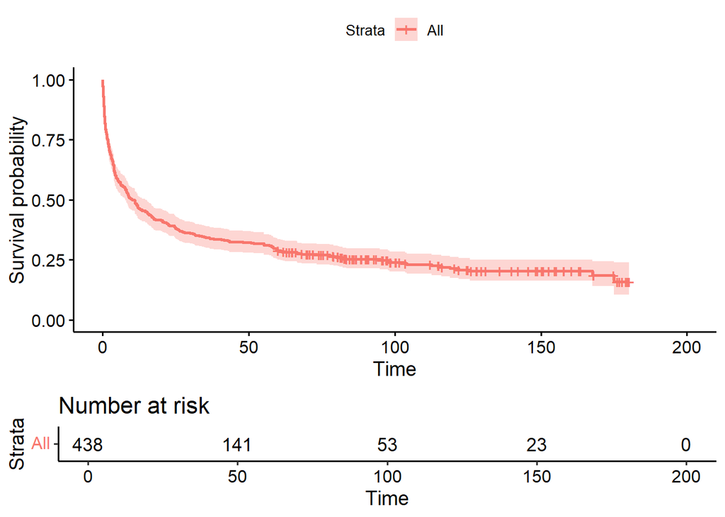

```r
ggsurvplot(KM1, data = Data_Survival_NHL, risk.table = TRUE, linetype = c(1,2), pval = TRUE)
```

```r
median_times <- surv_median(KM1)
print(median_times)
```

```
  strata   median    lower    upper
1    All 10.50411 7.726027 14.56438
```

## 3.4 Median Survival probability using Weibull (Parametric)

```r
weibull_fit <- survreg(Surv(duration_i_month, Data_Survival_NHL$`Alive:0_Death:1`) ~ 1,
                       data = Data_Survival_NHL,
                       dist = "weibull")

summary(weibull_fit)
```

```
Call:
survreg(formula = Surv(duration_i_month, Data_Survival_NHL$`Alive:0_Death:1`) ~
    1, data = Data_Survival_NHL, dist = "weibull")
             Value Std. Error    z      p
(Intercept) 3.6022     0.1237 29.1 <2e-16
Log(scale)  0.8199     0.0455 18.0 <2e-16

Scale= 2.27

Weibull distribution
Loglik(model)= -1413.8   Loglik(intercept only)= -1413.8
Number of Newton-Raphson Iterations: 5
n= 438
```

```r
mu <- coef(weibull_fit)
sigma <- weibull_fit$scale

weibull_median <- exp(mu) * (log(2))^sigma
print(paste("Weibull median survival time:", round(weibull_median, 2), "months"))
```

```
[1] "Weibull median survival time: 15.96 months"
```

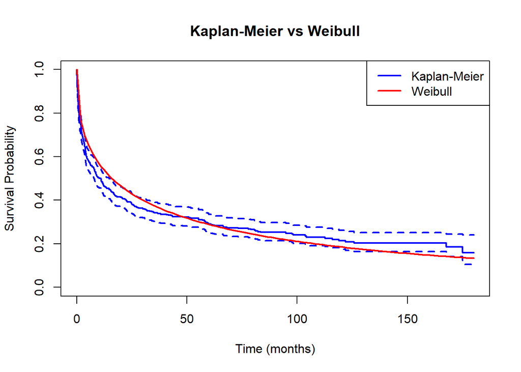

```r
# Kaplan-Meier estimate
km_fit <- survfit(Surv(duration_i_month,Data_Survival_NHL$`Alive:0_Death:1`) ~ 1, data = Data_Survival_NHL)

# Plot KM curve
plot(km_fit, col = "blue", lwd = 2, xlab = "Time (months)", ylab = "Survival Probability",
     main = "Kaplan-Meier vs Weibull")

# Overlay Weibull survival curve
curve(pweibull(x, shape = 1 / sigma, scale = exp(mu), lower.tail = FALSE),
      from = 0, to = max(Data_Survival_NHL$duration_i_month, na.rm = TRUE),
      col = "red", lwd = 2, add = TRUE)

legend("topright", legend = c("Kaplan-Meier", "Weibull"),
       col = c("blue", "red"), lwd = 2)
```

### 3.4.1 Interpretation

Kaplan-Meier estimation is more appropriate for reporting median survival time when the goal is to describe the observed data without assuming a specific hazard function, as it provides a non-parametric, assumption-free estimate that accurately reflects the empirical survival experience of the study population.

## 3.5 Cumulative Hazard Function Estimate

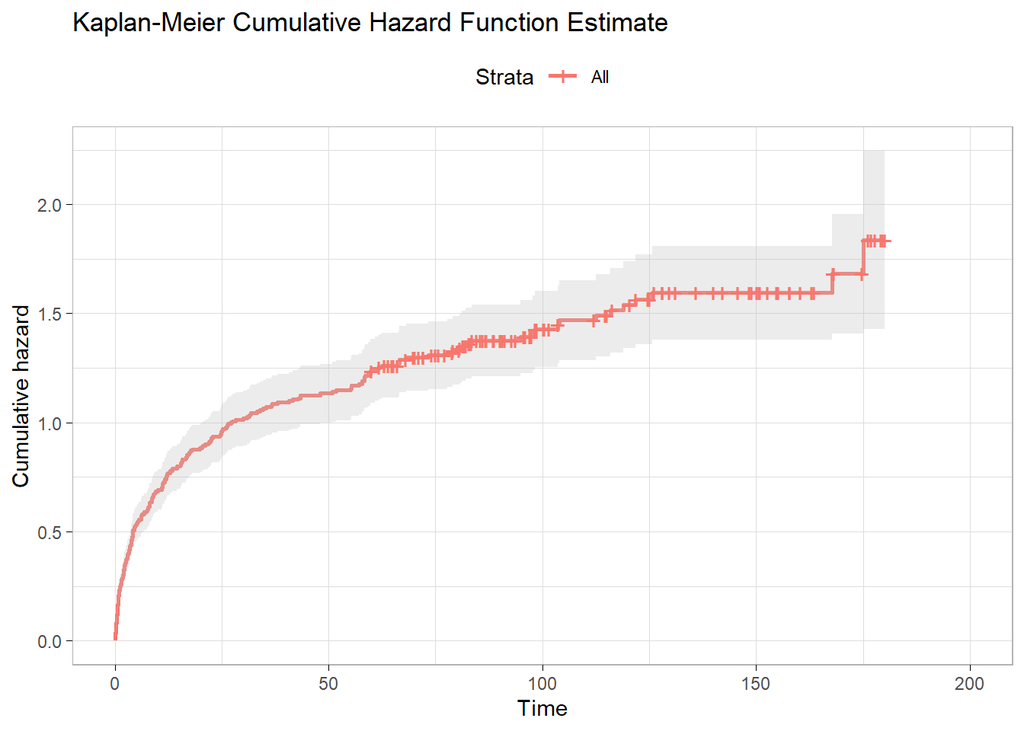

```r
ggsurvplot(
  KM1,
  fun = "cumhaz",
  pval.method = TRUE,
  conf.int = TRUE,
  ggtheme = theme_light(),
  title = "Kaplan-Meier Cumulative Hazard Function Estimate"
)
```

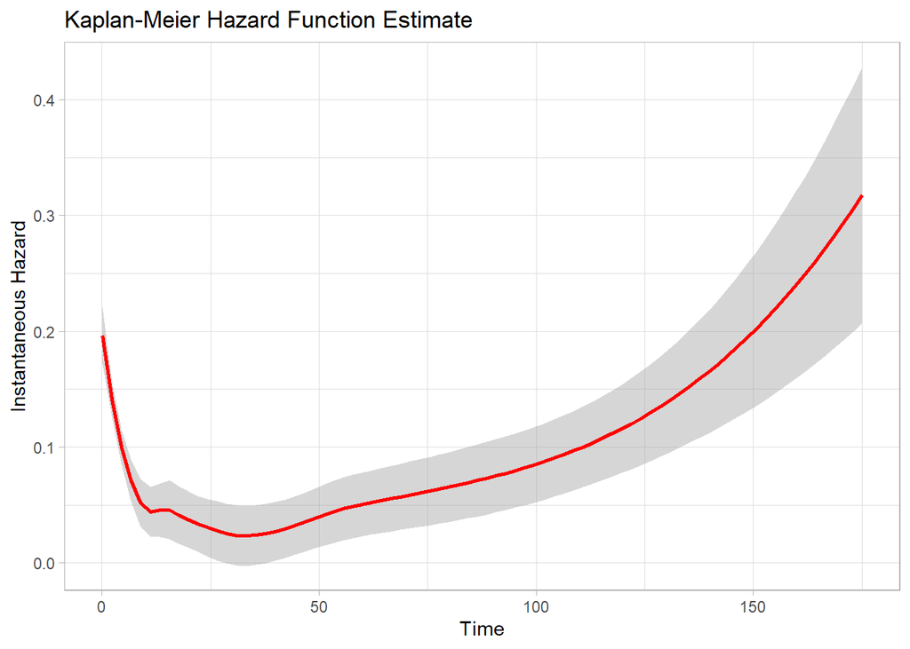

```r
epiR::epi.insthaz(KM1) %>%
  ggplot(aes(x = time, y = hest)) +
  geom_smooth(color = "red", method = "loess", formula = "y ~ x") +
  theme_light() +
  labs(title = "Kaplan-Meier Hazard Function Estimate",
       x = "Time", y = "Instantaneous Hazard")
```